# LB1_day2_memo

Kien Knot

2019/11/7

## 2日目

### 『状態空間モデルによる時系列解析 KFASによる実践モデリング』

- データは[ここ](https://sites.google.com/site/shunichinomu/home/kalmanfilter)から誰でもDL可能。

#### 時系列モデルとは

時系列は時間に依存して変化するデータ系列。いろいろなパターンがある。

- 連続か離散か。
- 周期的な変化があるか、ないか
- 定常的な時系列か、非定常な時系列か。

代表的な時系列モデルにはいくつかあり

- ホワイトノイズ
  - 時系列$\eta_t$が独立同分布の正規分布($\mu$, $\sigma$)に従うノイズ。
- ランダムウォーク
- 自己回帰モデル
  - 定常AR(1)モデル: 1時点前の値を用いて、パラメータ$\phi$の値が$-1 < \phi < 1$を満たす

がある。 ホワイトノイズとランダムウォークは以下の実装で確認しよう。  
なお、自己回帰モデルは`stats::arima()`などで推定できる。  
(パラメータの推定をフルスクラッチで実装できたらいいのになあ)

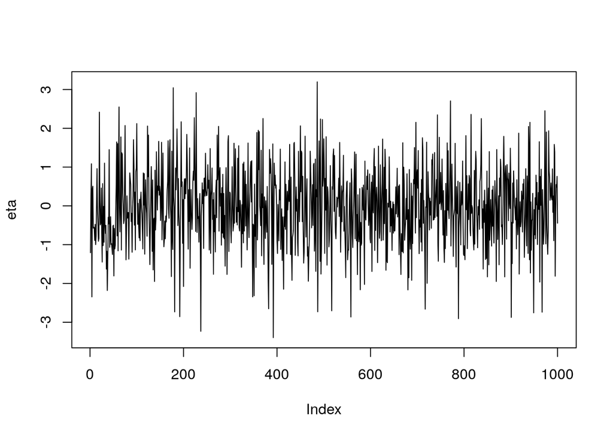

```r
set.seed(1234)

# ホワイトノイズ
eta <- rnorm(1000, mean = 0, sd = 1) # 普通に時系列する

plot(eta, type = "l") # ガチャガチャしてる
```

```r
summary(eta)
```

```
##     Min.  1st Qu.   Median     Mean  3rd Qu.     Max.
## -3.39606 -0.67325 -0.03979 -0.02660  0.61582  3.19590
```

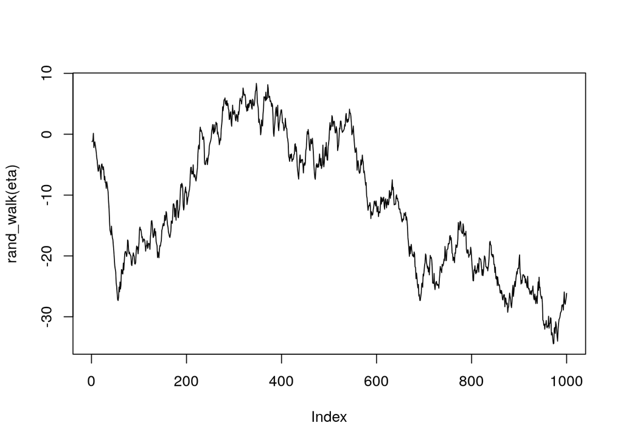

```r
# ランダムウォーク
rand_walk <- function(eta){
  alpha    <- numeric(length(eta))
  alpha[1] <- eta[1]
  for(time in 2:length(eta)){
    alpha[time] <- sum(eta[1:(time-1)])
  }
  return(alpha)
}

plot(rand_walk(eta), type = "l") # 確かに発散してそう。
```

```r
summary(rand_walk(eta))
```

```
##    Min. 1st Qu.  Median    Mean 3rd Qu.    Max.
## -34.437 -21.341 -12.710 -11.972  -1.782   8.352
```

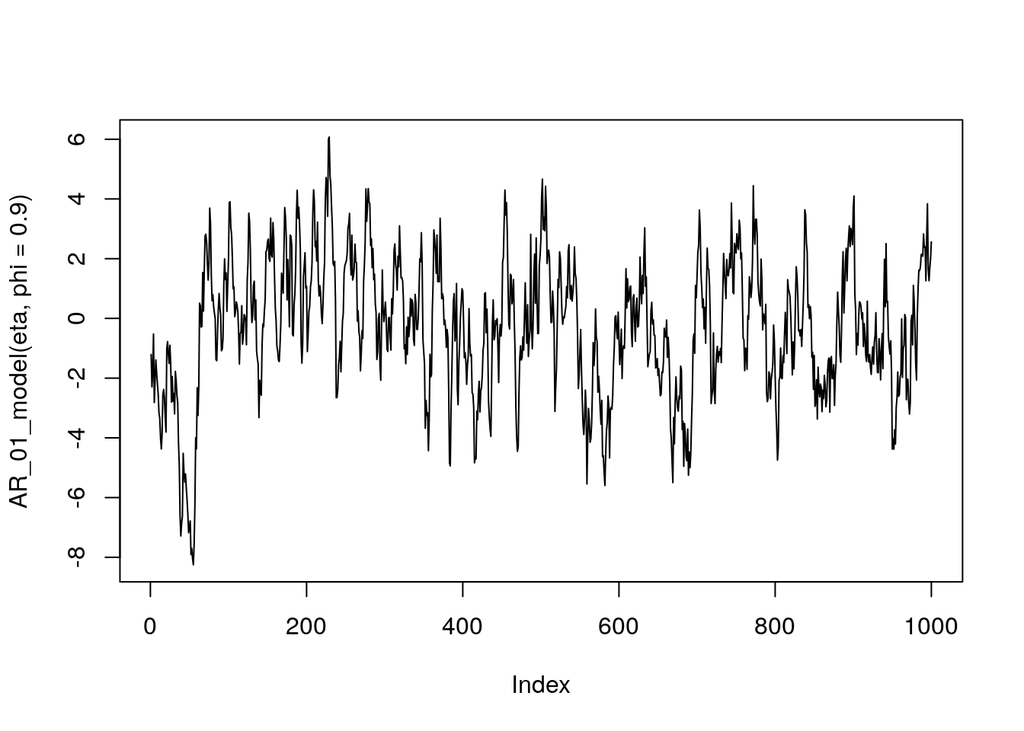

```r
# 自己回帰・定常AR(1)モデル
## パラメータ決め打ち
AR_01_model <- function(eta, phi){
  v    <- numeric(length(eta))
  v[1] <- eta[1]
  for(time in 2:length(eta)){
    v[time] <- phi * v[time-1] + eta[time-1]
  }
  return(v)
}

plot(AR_01_model(eta, phi = 0.9), type = "l")
```

```r
summary(AR_01_model(eta, phi = 0.9)) # ランダムウォークよりなんかアレ
```

```
##    Min. 1st Qu.  Median    Mean 3rd Qu.    Max.
## -8.2505 -1.7097 -0.1988 -0.2966  1.2965  6.0751
```

ホワイトノイズは完全にランダムっぽいが、ランダムウォークはなんか「意志」を感じる。  
定常AR(1)モデルはホワイトノイズに近いけど、なんか規則性を感じる。

#### 状態空間モデルとは

観測モデルと状態モデルに分ける。

- 観測モデル
  - ある確率分布から観測値を生成する
- 状態モデル
  - 観測モデルのパラメータの時間推移を表現する。

状態空間モデルの目的は「**状態**の推定・予測」にある。つまり、ある観測が得られた要因を推定し、要因の変化に基づいて将来の観測のアタリをつける。  
メリットとして、観測可能なデータの増減の要因を複数に分解できる。  
欠損値があってもある程度「どのへんに収まるか？」がわかる。

グラフィカルモデルで書くと、ハイパーパラメタから独立に状態モデルのパラメータが決まるのが階層ベイズのランダム効果モデルで、  
ハイパーパラメタから得られる状態モデルの間に(ある方向での)依存関係があるのが状態空間モデル。

- 状態空間モデルと用語について(文脈の確認)
  - フィルタ: 今**現在**の状態を知りたい場合
    - カルマンフィルタによる推定を行う。
  - 平滑化 : 今までの状態(=**過去**)の状態を知りたい
    - 平滑化漸化式(カルマンスムーザ)
  - 予測 : **将来**の状態を知りたい
    - 長期予測漸化式を用いる。

でも基本はカルマンフィルタ。カルマンフィルタはなんもわからん。  
この講義では`KFAS`を用いる。なんか`dlm`とかもあるんですけど、`dlm`は正規線形状態空間モデルが使える一方  
`KFAS`だと一般化線形状態空間モデルを扱える。強いとのこと。

#### ローカルレベルモデル

- 例: 野村先生の体重と体脂肪率
  - まずは素直にデータを見てみよう

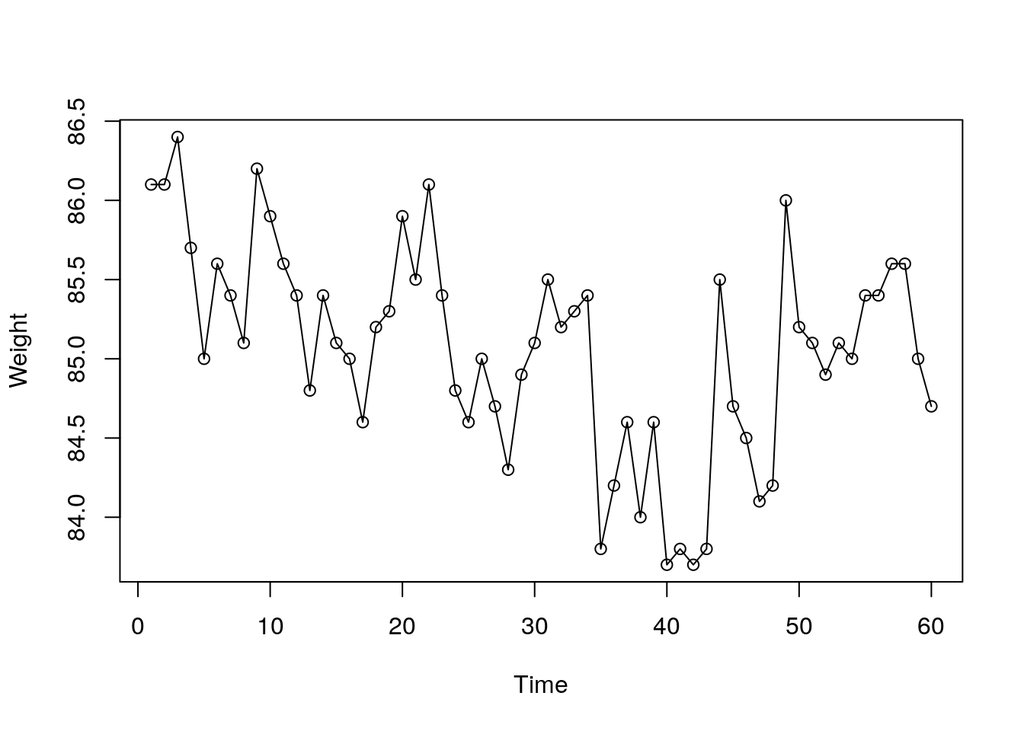

```r
library(KFAS)

# 体重データの読み込み（パス指定が必要。難しければ、データ読み込み済.RDataを起動すれば最初からデータが入っています）
Weight <- ts(scan("リーディングDAT講座のソースコード/Weight.dat"))

plot(Weight, type = "o")
```

- なんか規則性ありそうだな。
- カルマンフィルタで「現在の状態」を推定する。
  - `KFAS::KFAS`で実行が可能らしい。
- これがカルマンフィルタによる「現在の状態」の記述。
  - 各時点の状態をその時点までの観測値から予測
  - つまり時点30の状態は、時点30までの状態の結果から予測される。

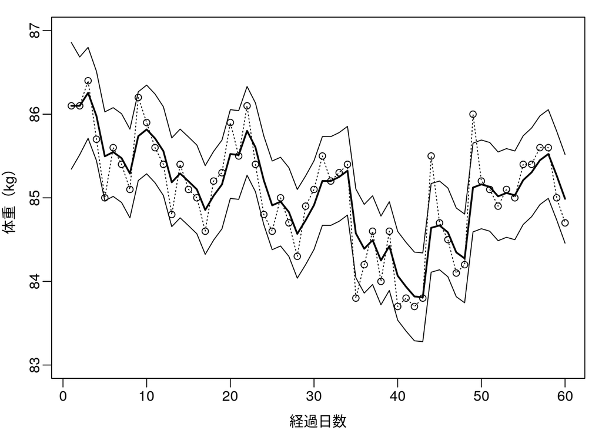

```r
# ローカルレベルモデルの定義
mod <- SSModel(Weight ~ SSMtrend(1, Q = NA), H = NA)

# 未知パラメータの推定
fit <- fitSSM(mod, numeric(2), method = "BFGS")

# カルマンフィルタ・カルマンスムーザの実行
kfs <- KFS(fit$model)

# フィルタ化推定量とその信頼区間
afilt <- kfs$att
Pfilt <- kfs$Ptt[,,]
afiltupper <- afilt+sqrt(Pfilt)*qnorm(0.975)
afiltlower <- afilt-sqrt(Pfilt)*qnorm(0.975)

# スライド番号17の図の描画
par(mar=c(3,3,1,1))
par(mgp=c(2,.5,0))
plot(Weight,type="o",lty=3,xlab="経過日数",ylab="体重（kg）",ylim=c(83,87))
lines(afilt,lwd=2)
lines(afiltupper)
lines(afiltlower)
```

- カルマンスムーザは、各時点の状態を、期間すべての観測値から推定する。

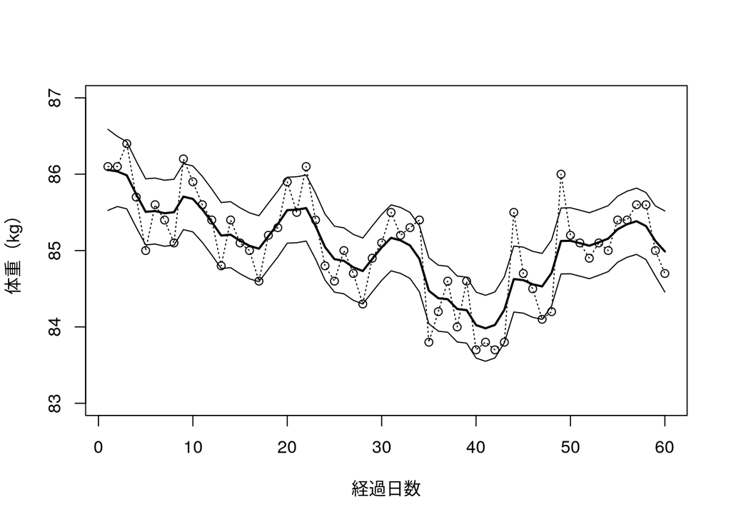

```r
# 平滑化状態の信頼区間
alphahatconf <- predict(fit$model, interval = "confidence", level = 0.95)

# スライド番号18の図の描画
plot(Weight,type="o",lty=3,xlab="経過日数",ylab="体重（kg）",ylim=c(83,87))
lines(alphahatconf[,1],lwd=2)
lines(alphahatconf[,2])
lines(alphahatconf[,3])
```

- 予測。
  - みんな大好き`predict`でOK。

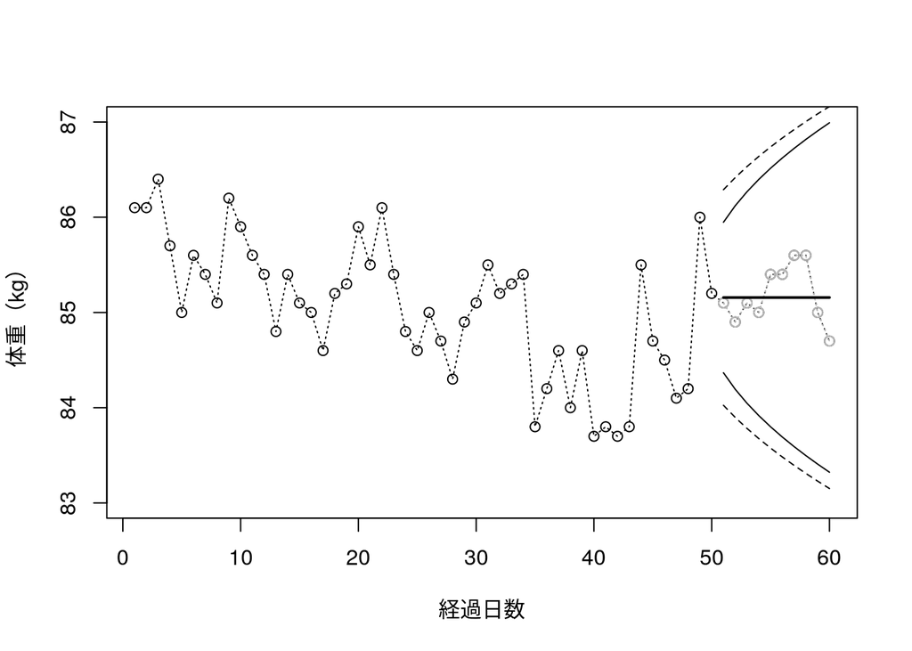

```r
# 長期予測
mod50 <- SSModel(Weight[1:50] ~ SSMtrend(1, Q = NA), H = NA)
fit50 <- fitSSM(mod50, numeric(2), method = "BFGS")
conf50 <- predict(fit50$model, interval ="confidence", n.ahead = 10)
pre50  <- predict(fit50$model, interval ="prediction", n.ahead = 10)

# スライド番号20の図の描画
plot(Weight,type="o",lty=3,xlab="経過日数",ylab="体重（kg）",ylim=c(83,87))
lines(51:60,Weight[51:60],type="o",lty=3,col=8)
lines(51:60,conf50[,1],lwd=2)
lines(51:60,conf50[,2])
lines(51:60,conf50[,3])
lines(51:60,pre50[,2],lty=2)
lines(51:60,pre50[,3],lty=2)
```

- 欠損値補完は省略。

#### 平滑化トレンドモデル